# AE-CH8 / HW-CH8

Author

Your Name Here

This Application Exercise walks through the guided activities in Chapter 8 of the textbook. There are spaces for you to answer each question (with code and/or text). Feel free to also use this document to add your own notes along the way.

## Load packages & data

```r
library(tidyverse)
library(janitor)
library(broom)
theme_set(theme_minimal())

cancer <- read_csv("./data/C8 CancerCluster.csv") %>%
  clean_names()
```

# Cancer data

## Question 1

```r
67/1138
```

```
[1] 0.05887522
```

Proportion of people who reported cancer diagnosis was 67/1138 = 0.0589

## Question 2

```r
person_years <- 1138*25
```

Number of person-years was 28450

## Question 3

```r
cancer_rate <- 67/person_years
cir <- cancer_rate*100000
```

Observed cancer rate was 0.00236.

Observed cancer incidence rate (CIR) was 235.5

## Question 4

```r
expected <- 326/100000*person_years
expected
```

```
[1] 92.747
```

> The observed count of 67 is actually lower than the expected count, meaning 67 is not indicative of a cancer cluster in Randolph.

## Question 5

```r
person_years2 <- 1138*12.5
expected2 <- 326/100000*person_years2
expected2
```

```
[1] 46.3735
```

> 67 does now seem higher than the expected count of 46.4. We should incorporate statistical uncertainty before determining whether this is unusually high.

## Question 6

> Assumption A could be false if family members within a household are systematically more or less likely than their neighbors to get screened, perhaps due to a famliy history of cancer. More screening means higher likelihood of discovering cancer.

## Question 7

> Different ages might have different probability of diagnosis. Younger people are less likely to get cancer than older people.

## Question 8

> Different familial disease history and wealth might influence how likely people are to visit a hospital and receive a diagnosis.

## Question 9

```r
years <- 25
n <- 1138
person_years <- n*years
incidence_rate <- 326/100000

#simulate cases for a single neighborhood
rbinom(1, size = person_years,
       prob = incidence_rate)
```

```
[1] 95
```

```r
#simulate 10,000 neighborhoods
sims <- rbinom(10000, size = person_years,
               prob = incidence_rate)
#view summary of simulations
#sanity check- should get mean & median around 93
summary(sims)
```

```
   Min. 1st Qu.  Median    Mean 3rd Qu.    Max.
  59.00   86.00   93.00   92.84   99.00  135.00
```

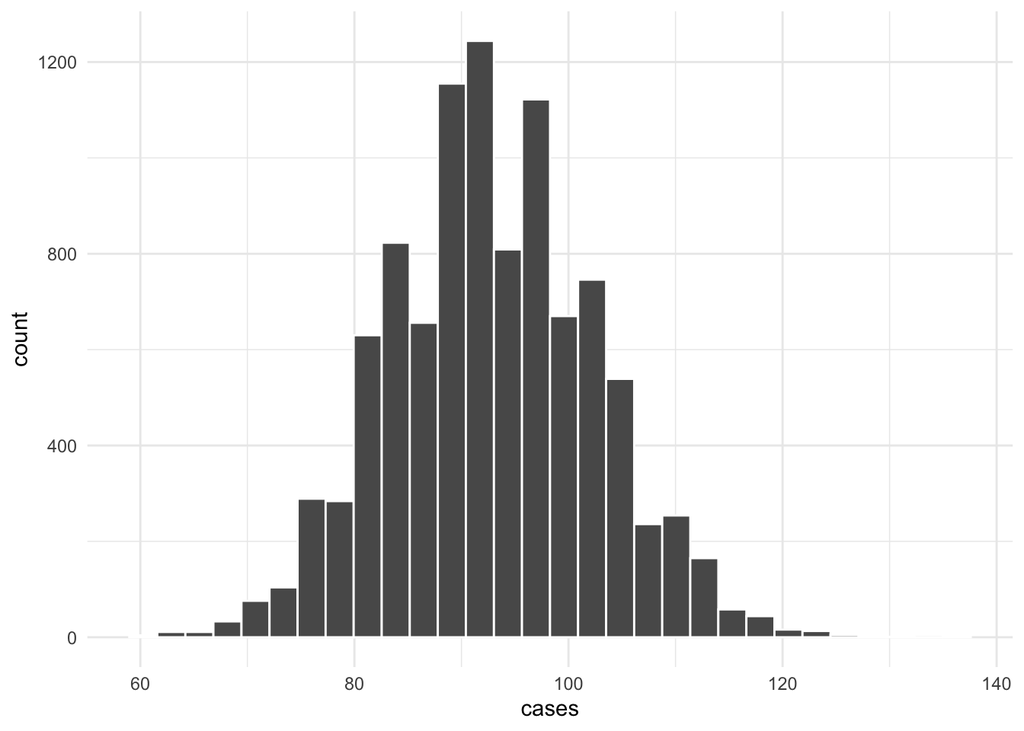

```r
#plot simulations
sims <- data.frame(cases = sims)
ggplot(sims, aes(x = cases)) +
  geom_histogram(color = "white")
```

```r
#compute p-value
sum(sims$cases > 67)/nrow(sims)
```

```
[1] 0.9968
```

## Question 10

```r
years <- 12.5
n <- 1138
person_years <- n*years
incidence_rate <- 326/100000

#simulate cases for a single neighborhood
rbinom(1, size = person_years,
       prob = incidence_rate)
```

```
[1] 47
```

```r
#simulate 10,000 neighborhoods
sims <- rbinom(10000, size = person_years,
               prob = incidence_rate)
#view summary of simulations
summary(sims)
```

```
   Min. 1st Qu.  Median    Mean 3rd Qu.    Max.
  22.00   42.00   46.00   46.28   51.00   72.00
```

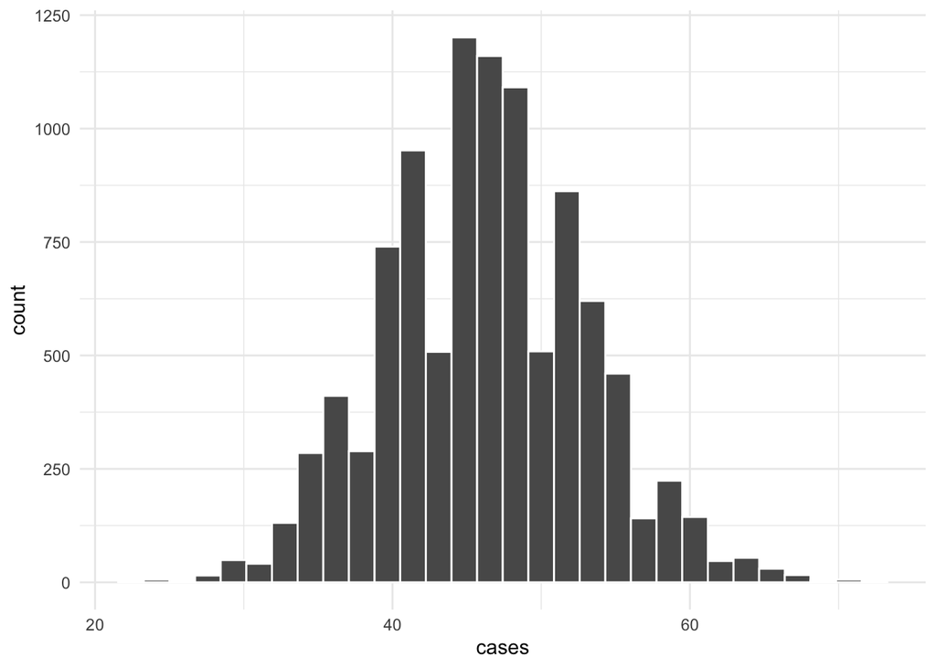

```r
#plot simulations
sims <- data.frame(cases = sims)
ggplot(sims, aes(x = cases)) +
  geom_histogram(color = "white")
```

```r
#compute p-value
sum(sims$cases > 67)/nrow(sims)
```

```
[1] 0.0018
```

## Skip 11 - 14

## Question 15

```r
glimpse(cancer)
```

```
Rows: 8
Columns: 6
$ location     <chr> "BGA", "BGA", "BGA", "BGA", "CTR", "CTR", "CTR", "CTR"
$ cases        <dbl> 4, 25, 8, 12, 752, 2422, 1612, 5465
$ person_years <dbl> 14489.0, 5431.0, 1682.0, 3398.0, 839007.5, 517613.0, 1566…
$ rate         <dbl> 27.6, 460.3, 475.7, 353.2, 89.6, 467.9, 1028.9, 1912.2
$ age_group    <chr> "17-43", "44-59", "60-64", "65-79", "17-43", "44-59", "60…
$ median_age   <dbl> 30.0, 51.5, 62.0, 72.0, 30.0, 51.5, 62.0, 72.0
```

```r
bga_data <- cancer %>%
  filter(location == "BGA")

m15 <- glm(cases ~ median_age + offset(log(person_years)),
          data = bga_data, family = "poisson")
tidy(m15)
```

| term | estimate | std.error | statistic | p.value |
| --- | --- | --- | --- | --- |
| (Intercept) | -8.66851736 | 0.515706760 | -16.809005 | 0.000000000000000000000000000000000000000000000000000000000000002096621 |
| median_age | 0.04921637 | 0.008773537 | 5.609638 | 0.000000020275039569787973204074778992879457550913002705783583223819733 |

## Question 16

```r
b0 <- tidy(m15)[1,2] %>% pull()
b1 <- tidy(m15)[2,2] %>% pull()
rate_est <- exp(b0 + b1*62)
rate_est
```

```
[1] 0.003635159
```

```r
cir_est <- rate_est*100000
cir_est
```

```
[1] 363.5159
```

```r
cir_obs <- bga_data %>%
  filter(median_age == 62) %>%
  pull(rate)
cir_obs
```

```
[1] 475.7
```

```r
cir_obs - cir_est
```

```
[1] 112.1841
```

> The estimated CIR is 363.5 and the observed CIT is 475.7. The estimate is not very good (the values are not close).

## Question 17

```r
ctr_data <- cancer %>%
  filter(location == "CTR")

m17 <- glm(cases ~ median_age + offset(log(person_years)),
          data = ctr_data, family = "poisson")
tidy(m17)
```

| term | estimate | std.error | statistic | p.value |
| --- | --- | --- | --- | --- |
| (Intercept) | -9.07615437 | 0.0496234723 | -182.90043 | 0 |
| median_age | 0.07141667 | 0.0007780543 | 91.78879 | 0 |

> The $b_1$ estimate is larger for the CTR dataset, indicating that the log(cancer rate) is growing faster with age for this sample.

## Question 18

```r
#extract regression coefficients for m17
b0_m17 <- tidy(m17)[1,2] %>% pull()
b1_m17 <- tidy(m17)[2,2] %>% pull()

#compute CIR for CTR data (m17), age = 62
cir_est_m17_62 <- exp(b0_m17 + b1_m17*62)*100000
cir_est_m17_62
```

```
[1] 957.7669
```

```r
#extract observed CIR for CTR data, age = 62
cir_obs_62 <- ctr_data %>%
  filter(median_age == 62) %>%
  pull(rate)
cir_obs_62
```

```
[1] 1028.9
```

> For median age of 62 years:

> the estimated cancer incidence rate (CIR) is $\hat{\lambda/t} = exp(-9.0761544 + 0.0714167(62))*100000 = 957.7668895$

> the observed CIR is 1028.9

> these two values are fairly close (difference of -71.1331105)

```r
#compute CIR for CTR data (m17), age = 72
cir_est_m17_72<- exp(b0_m17 + b1_m17*72)*100000
cir_est_m17_72
```

```
[1] 1956.223
```

```r
#extract observed CIR for CTR data, age = 72
cir_obs_72 <- ctr_data %>%
  filter(median_age == 72) %>%
  pull(rate)
cir_obs_72
```

```
[1] 1912.2
```

> the estimated cancer incidence rate (CIR) is $\hat{\lambda/t} = exp(-9.0761544 + 0.0714167(72))*100000 = 1956.22345$

> the observed CIR is 1912.2

> these two values are fairly close (difference of 44.02345)

## Question 19

```r
exp(b1_m17*10)
```

```
[1] 2.042484
```

Cancer incidence rates are estimated to be 2.04 times higher for each additional 10 years in median age.

## Question 20

```r
m20 <- glm(cases ~ median_age + offset(log(person_years)),
          data = cancer, family = "poisson")
tidy(m20)
```

| term | estimate | std.error | statistic | p.value |
| --- | --- | --- | --- | --- |
| (Intercept) | -9.07602672 | 0.0493786708 | -183.80460 | 0 |
| median_age | 0.07130271 | 0.0007744889 | 92.06421 | 0 |

> This model probably does not make sense because the estimated coefficients for median age are very different for the two locations.

## Question 21

```r
m21 <- glm(cases ~ location + offset(log(person_years)),
          data = cancer, family = "poisson")
tidy(m21)
```

| term | estimate | std.error | statistic | p.value |
| --- | --- | --- | --- | --- |
| (Intercept) | -6.234811 | 0.1428547 | -43.644422 | 0.00000000000000000000 |
| locationCTR | 1.067151 | 0.1431957 | 7.452392 | 0.00000000000009166276 |

```r
b1_m21 <- tidy(m21)[2,2] %>% pull()
exp(b1_m21)
```

```
[1] 2.907084
```

> The CIR is 2.91 times higher for CTR compared to BGA.

## Question 22

```r
m22 <- glm(cases ~ median_age + location +
             offset(log(person_years)),
          data = cancer, family = "poisson")
tidy(m22)
```

| term | estimate | std.error | statistic | p.value |
| --- | --- | --- | --- | --- |
| (Intercept) | -9.97304684 | 0.1506198190 | -66.213377 | 0.0000000000000000 |
| median_age | 0.07126501 | 0.0007748612 | 91.971327 | 0.0000000000000000 |
| locationCTR | 0.90636949 | 0.1431997770 | 6.329406 | 0.0000000002461072 |

```r
b1_m22 <- tidy(m22)[2,2] %>% pull()
b2_m22 <- tidy(m22)[3,2] %>% pull()
exp(b1_m22)
```

```
[1] 1.073866
```

```r
exp(b2_m22)
```

```
[1] 2.47532
```

> Adjusting for location, the CIR is estimated to increase by 1.07 times on average for each additional year in median age.

> Adjusting for median age, the CTR location is estimated to be 2.48 times higher than the BGA location.

## Question 23

> Adjusting for median age, the CTR location is estimated to be 2.48 times higher than the BGA location.

## Question 24

> The CTR data are not linear - they appear to follow an exponential distribution

## Question 25

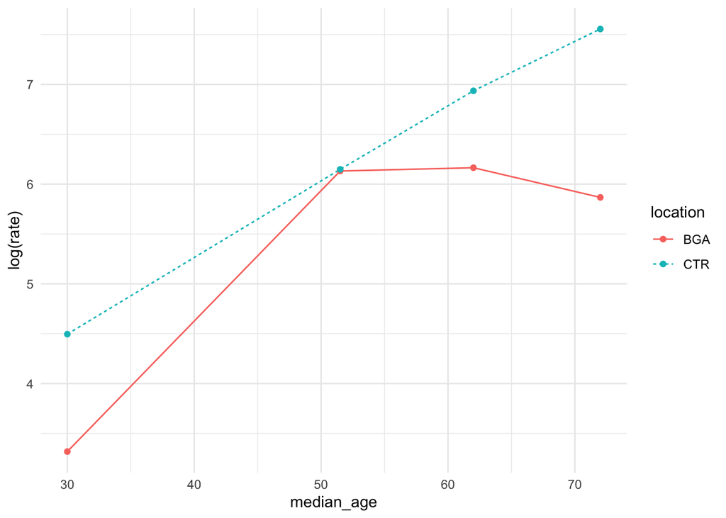

```r
ggplot(cancer, aes(x = median_age,
                   y = log(rate),
                   group = location,
                   color = location,
                   linetype = location)) +
  geom_line() +
  geom_point()
```

> The CTR data are now linear but hte BGA data are not

## Question 26

> No, we cannot use the same general discription for both locations.

## Question 27

```r
m27 <- glm(cases ~ median_age*location +
             offset(log(person_years)),
          data = cancer, family = "poisson")
tidy(m27)
```

| term | estimate | std.error | statistic | p.value |
| --- | --- | --- | --- | --- |
| (Intercept) | -8.66851736 | 0.515706760 | -16.8090047 | 0.000000000000000000000000000000000000000000000000000000000000002096621 |
| median_age | 0.04921637 | 0.008773537 | 5.6096379 | 0.000000020275039569781213484108995650720408399081406969344243407249451 |
| locationCTR | -0.40763701 | 0.518088754 | -0.7868092 | 0.431393556874636818765367252126452513039112091064453125000000000000000 |
| median_age:locationCTR | 0.02220030 | 0.008807970 | 2.5204785 | 0.011719539896013080743086831603250175248831510543823242187500000000000 |

## Question 28

```r
b0_m27 <- tidy(m27)[1,2] %>% pull()
b1_m27 <- tidy(m27)[2,2] %>% pull()
b2_m27 <- tidy(m27)[3,2] %>% pull()
b3_m27 <- tidy(m27)[4,2] %>% pull()
```

$$BGA \text{ (location = 0)}: \hat{\lambda}/t = exp(b_0 + b_1x) = exp(-8.669 + 0.049x)$$

$$CTR \text{ (location = 1)}: \hat{\lambda}/t = exp((b_0 + b_2) + (b_1 + b_3)x) = exp(-9.076 + 0.071x)$$

## Question 29

```r
exp((b1_m27 + b3_m27)*10) #ctr
```

```
[1] 2.042484
```

```r
exp((b1_m27)*10) #bga
```

```
[1] 1.635852
```

> CTR location: exp(0.071*10) = 2.04 times higher

> BGA location: exp(0.049*10) = 1.64 times higher

## Question 30

```r
tidy(m27)
```

| term | estimate | std.error | statistic | p.value |
| --- | --- | --- | --- | --- |
| (Intercept) | -8.66851736 | 0.515706760 | -16.8090047 | 0.000000000000000000000000000000000000000000000000000000000000002096621 |
| median_age | 0.04921637 | 0.008773537 | 5.6096379 | 0.000000020275039569781213484108995650720408399081406969344243407249451 |
| locationCTR | -0.40763701 | 0.518088754 | -0.7868092 | 0.431393556874636818765367252126452513039112091064453125000000000000000 |
| median_age:locationCTR | 0.02220030 | 0.008807970 | 2.5204785 | 0.011719539896013080743086831603250175248831510543823242187500000000000 |

> yes, the relevant p-value is the one for the interaction term. Since it is small, there is evidence to suggest the location does affect the relationship between age and log-CIR.

## Question 31

```r
summary_restricted <- summary(m22) #no interaction
summary_restricted
```

```
Call:
glm(formula = cases ~ median_age + location + offset(log(person_years)),
    family = "poisson", data = cancer)

Coefficients:
              Estimate Std. Error z value             Pr(>|z|)
(Intercept) -9.9730468  0.1506198 -66.213 < 0.0000000000000002 ***
median_age   0.0712650  0.0007749  91.971 < 0.0000000000000002 ***
locationCTR  0.9063695  0.1431998   6.329       0.000000000246 ***
---
Signif. codes:  0 '***' 0.001 '**' 0.01 '*' 0.05 '.' 0.1 ' ' 1

(Dispersion parameter for poisson family taken to be 1)

    Null deviance: 11539.630  on 7  degrees of freedom
Residual deviance:    46.296  on 5  degrees of freedom
AIC: 106.66

Number of Fisher Scoring iterations: 5
```

```r
summary_full <- summary(m27) #interaction
summary_full
```

```
Call:
glm(formula = cases ~ median_age * location + offset(log(person_years)),
    family = "poisson", data = cancer)

Coefficients:
                        Estimate Std. Error z value             Pr(>|z|)
(Intercept)            -8.668517   0.515707 -16.809 < 0.0000000000000002 ***
median_age              0.049216   0.008774   5.610         0.0000000203 ***
locationCTR            -0.407637   0.518089  -0.787               0.4314
median_age:locationCTR  0.022200   0.008808   2.520               0.0117 *
---
Signif. codes:  0 '***' 0.001 '**' 0.01 '*' 0.05 '.' 0.1 ' ' 1

(Dispersion parameter for poisson family taken to be 1)

    Null deviance: 11539.630  on 7  degrees of freedom
Residual deviance:    40.453  on 4  degrees of freedom
AIC: 102.82

Number of Fisher Scoring iterations: 5
```

```r
G <- summary_restricted$deviance - summary_full$deviance
G
```

```
[1] 5.842672
```

```r
df <- summary_restricted$df.residual - summary_full$df.residual
pchisq(G, df, lower.tail = FALSE)
```

```
[1] 0.01564206
```

> The LRT G-statistic is 5.84, which follows a chi-squared distribution with 1 degree of freedom. The p-value is 0.016, therefore there is sufficient evidence to conclude there is a significant interaction between age and location. The sample size is large enough here because all predicted means $\hat{\lambda}_i$ are larger than 5, as shown below.

```r
cancer <- cancer %>%
  mutate(location_01 = if_else(location == "BGA", 0, 1),
         lambda_hat_m27 = person_years*exp(b0_m27 + b1_m27*median_age + b2_m27*location_01 + b3_m27*median_age*location_01))
cancer %>% pull(lambda_hat_m27)
```

```
[1]   10.903880   11.775301    6.114337   20.206482  817.556940 2342.062179
[7] 1500.533386 5590.847496
```

## Question 32

> A quadratic model may be more appropriate, but with only 4 data points it’s hard to discern.

## Question 33

```r
ctr_data <-
m33 <- glm(cases ~ median_age + I(median_age^2) + offset(log(person_years)),
          data = ctr_data, family = "poisson")
summary(m33)
```

```
Call:
glm(formula = cases ~ median_age + I(median_age^2) + offset(log(person_years)),
    family = "poisson", data = ctr_data)

Coefficients:
                   Estimate  Std. Error z value             Pr(>|z|)
(Intercept)     -9.72711624  0.16940333 -57.420 < 0.0000000000000002 ***
median_age       0.09710755  0.00639201  15.192 < 0.0000000000000002 ***
I(median_age^2) -0.00023492  0.00005781  -4.063            0.0000483 ***
---
Signif. codes:  0 '***' 0.001 '**' 0.01 '*' 0.05 '.' 0.1 ' ' 1

(Dispersion parameter for poisson family taken to be 1)

    Null deviance: 11402.8343  on 3  degrees of freedom
Residual deviance:     2.4259  on 1  degrees of freedom
AIC: 46.184

Number of Fisher Scoring iterations: 3
```

```r
deviance_stat <- summary(m33)$deviance
df <- summary(m33)$df.residual
pchisq(deviance_stat, df, lower.tail = FALSE)
```

```
[1] 0.1193422
```

> With a p-value of 0.119, there is not evidence that the model is a poor fit (see page 269).

## Question 34

```r
summary(m27)
```

```
Call:
glm(formula = cases ~ median_age * location + offset(log(person_years)),
    family = "poisson", data = cancer)

Coefficients:
                        Estimate Std. Error z value             Pr(>|z|)
(Intercept)            -8.668517   0.515707 -16.809 < 0.0000000000000002 ***
median_age              0.049216   0.008774   5.610         0.0000000203 ***
locationCTR            -0.407637   0.518089  -0.787               0.4314
median_age:locationCTR  0.022200   0.008808   2.520               0.0117 *
---
Signif. codes:  0 '***' 0.001 '**' 0.01 '*' 0.05 '.' 0.1 ' ' 1

(Dispersion parameter for poisson family taken to be 1)

    Null deviance: 11539.630  on 7  degrees of freedom
Residual deviance:    40.453  on 4  degrees of freedom
AIC: 102.82

Number of Fisher Scoring iterations: 5
```

```r
pchisq(summary(m27)$deviance,
       df = summary(m27)$df.residual,
       lower.tail = FALSE)
```

```
[1] 0.00000003487687
```

> The deviance on the interaction model in 27 is 40.5 with 4 degrees of freedom, yielding a p-value of 0. This indicates the model may not be a good fit. Looking at the individual deviance residuals shows that some of them are larger than 2 in magnitude. A plot indicates a quadratic term may be appropriate.

```r
summary(m27)$deviance.resid
```

```
         1          2          3          4          5          6          7
-2.4052371  3.3457711  0.7277069 -1.9765225 -2.3244787  1.6425183  2.8429772
         8
-1.6894581
```

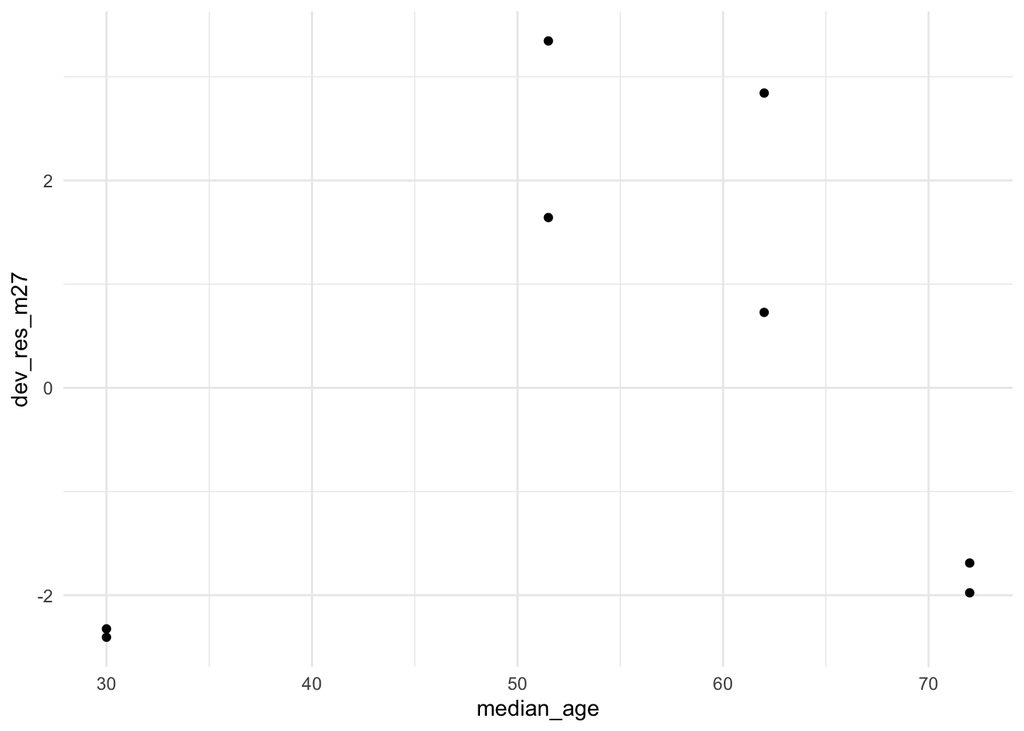

```r
cancer <- cancer %>%
  mutate(dev_res_m27 = summary(m27)$deviance.resid)
ggplot(cancer, aes(x = median_age,
                   y = dev_res_m27)) +
  geom_point()
```

To conduct a LRT for whether a quadratic term is appropriate, we fit a new model with an interaction term and a quadratic term and compare it to `m27`, which is the interaction model without the quadratic term.

```r
m34 <- glm(cases ~ median_age*location + I(median_age^2) +
             offset(log(person_years)),
          data = cancer, family = "poisson")
summary_restricted <- summary(m27) #no quadratic
summary_restricted
```

```
Call:
glm(formula = cases ~ median_age * location + offset(log(person_years)),
    family = "poisson", data = cancer)

Coefficients:
                        Estimate Std. Error z value             Pr(>|z|)
(Intercept)            -8.668517   0.515707 -16.809 < 0.0000000000000002 ***
median_age              0.049216   0.008774   5.610         0.0000000203 ***
locationCTR            -0.407637   0.518089  -0.787               0.4314
median_age:locationCTR  0.022200   0.008808   2.520               0.0117 *
---
Signif. codes:  0 '***' 0.001 '**' 0.01 '*' 0.05 '.' 0.1 ' ' 1

(Dispersion parameter for poisson family taken to be 1)

    Null deviance: 11539.630  on 7  degrees of freedom
Residual deviance:    40.453  on 4  degrees of freedom
AIC: 102.82

Number of Fisher Scoring iterations: 5
```

```r
summary_full <- summary(m34) #quadratic
summary_full
```

```
Call:
glm(formula = cases ~ median_age * location + I(median_age^2) +
    offset(log(person_years)), family = "poisson", data = cancer)

Coefficients:
                          Estimate  Std. Error z value             Pr(>|z|)
(Intercept)            -9.27516550  0.54255244 -17.095 < 0.0000000000000002 ***
median_age              0.07552476  0.01074416   7.029     0.00000000000207 ***
locationCTR            -0.50767410  0.52772751  -0.962              0.33605
I(median_age^2)        -0.00025484  0.00005768  -4.418     0.00000995622698 ***
median_age:locationCTR  0.02376808  0.00898311   2.646              0.00815 **
---
Signif. codes:  0 '***' 0.001 '**' 0.01 '*' 0.05 '.' 0.1 ' ' 1

(Dispersion parameter for poisson family taken to be 1)

    Null deviance: 11539.630  on 7  degrees of freedom
Residual deviance:    20.803  on 3  degrees of freedom
AIC: 85.166

Number of Fisher Scoring iterations: 5
```

```r
G <- summary_restricted$deviance - summary_full$deviance
G
```

```
[1] 19.65011
```

```r
df <- summary_restricted$df.residual - summary_full$df.residual
pchisq(G, df, lower.tail = FALSE)
```

```
[1] 0.000009299815
```

> There is significant evidence that a quadratic term should be included in the model.

# Galapagos

## Question 50

```r
gala <- read_csv("./data/C8 Gala.csv") %>%
  clean_names()
glimpse(gala)
```

```
Rows: 30
Columns: 8
$ island    <chr> "Baltra", "Bartolome", "Caldwell", "Champion", "Coamano", "D…
$ species   <dbl> 58, 31, 3, 25, 2, 18, 24, 10, 8, 2, 97, 93, 58, 5, 40, 347, …
$ endemics  <dbl> 23, 21, 3, 9, 1, 11, 0, 7, 4, 2, 26, 35, 17, 4, 19, 89, 23, …
$ area      <dbl> 25.09, 1.24, 0.21, 0.10, 0.05, 0.34, 0.08, 2.33, 0.03, 0.18,…
$ elevation <dbl> 346, 109, 114, 46, 77, 119, 93, 168, 71, 112, 198, 1494, 49,…
$ nearest   <dbl> 0.6, 0.6, 2.8, 1.9, 1.9, 8.0, 6.0, 34.1, 0.4, 2.6, 1.1, 4.3,…
$ scruz     <dbl> 0.6, 26.3, 58.7, 47.4, 1.9, 8.0, 12.0, 290.2, 0.4, 50.2, 88.…
$ adjacent  <dbl> 1.84, 572.33, 0.78, 0.18, 903.82, 1.84, 0.34, 2.85, 17.95, 0…
```

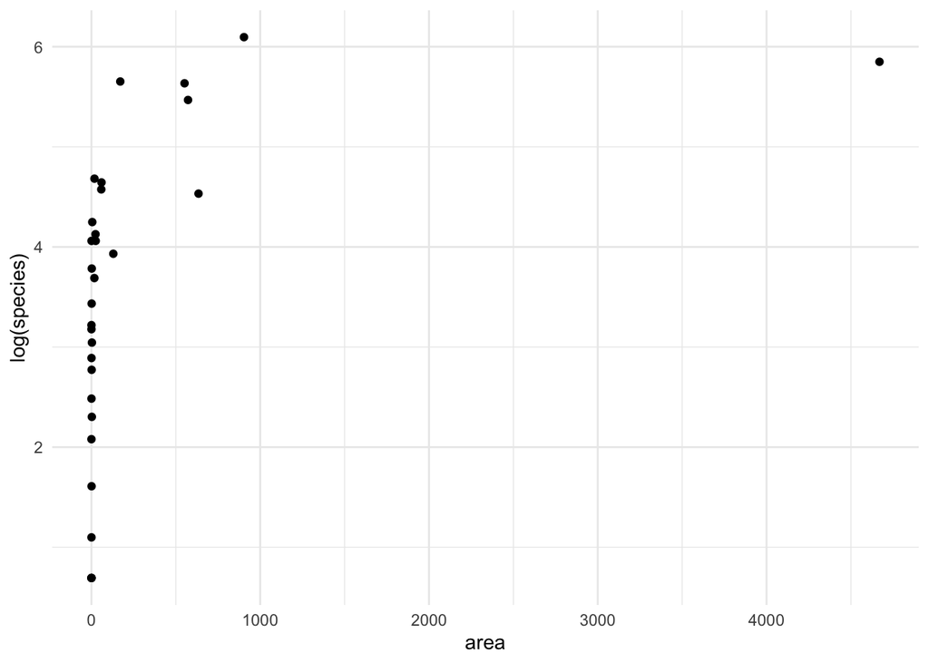

```r
create_plot <- function(explanatory){
  ggplot(gala, aes(x = !!sym(explanatory),
                   y = log(species))) +
    geom_point()
}
create_plot("area")
```

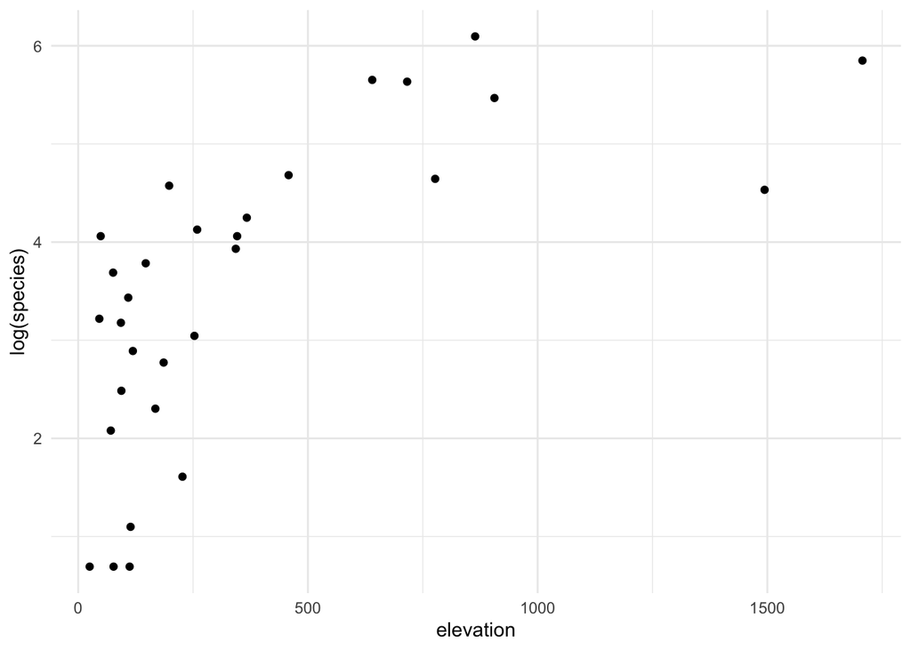

```r
create_plot("elevation")
```

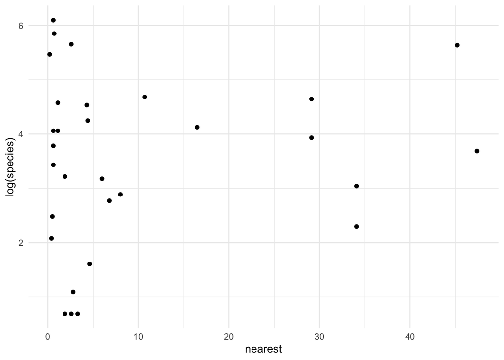

```r
create_plot("nearest")
```

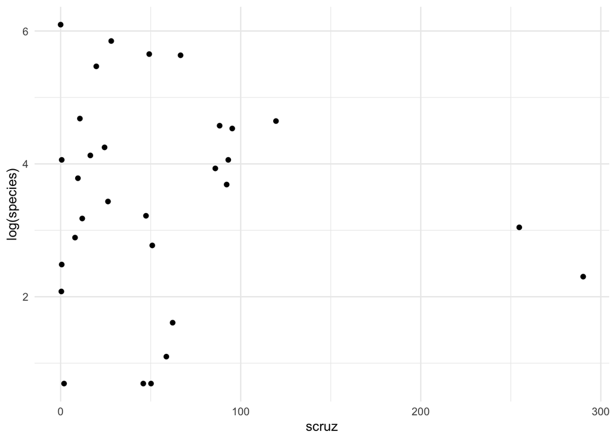

```r
create_plot("scruz")
```

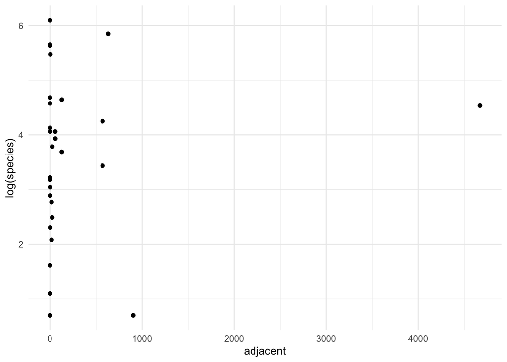

```r
create_plot("adjacent")
```

> Most of the covariates are not linearly related to the log(species) response variable, indicating a Poisson regression may not be best.